# Tutorial Part II - R goes spatial

Stephanie Kramer-Schadt, Pierre Gras, Moritz Wenzler

2019-03-19

# Useful (web)sites

1. R news and tutorials
- http://www.r-bloggers.com/
2. Quick introduction to spatial R
- http://pakillo.github.io/R-GIS-tutorial/
- http://rstudio-pubs-static.s3.amazonaws.com/7993_6b081819ba184047802a508a7f3187cb.html
3. Spatial visualisation
- check out the packages tmap, ggmap, leaflet and cartography
- https://cran.r-project.org/web/packages/tmap/vignettes/tmap-getstarted.html
- A whole book: https://serialmentor.com/dataviz/
4. overview over spatial packages
- http://cran.r-project.org/web/views/Spatial.html # http://cran.r-project.org/view=Spatial
- https://www.r-spatial.org/
5. R-cheatsheets
- in your folder
- or here: https://www.rstudio.com/resources/cheatsheets/
6. Infos about simple features in R (sf package)
- https://r-spatial.github.io/sf/index.html
- and nice intro: https://oliviergimenez.github.io/introspatialR/#1
7. Use EPSG codes as unique and specific identifies of your coordinate reference systsem instead of writing projection details. See http://spatialreference.org/ for EPSG codes or https://www.nceas.ucsb.edu/~frazier/RSpatialGuides/OverviewCoordinateReferenceSystems.pdf
8. BioMove specials:
- For analysis of plot-based biodiversity data: package **vegan**
- For analysis of telemetry data: packages **adehabitatHR, adehabitatLT, move,recurse, momentuHMM, moveHMM, ctmm**

## Further reading

1. Check Roger Bivand’s publications:
- http://cran.r-project.org/web/views/Spatial.html
- http://www.csiss.org/learning_resources/index.html
- Roger Bivand et al. 2008, Appied Spatial Data Analysis in R, Springer
2. Check Edzer Pebesma’s course materials and publications:
- http://ifgi.uni-muenster.de/~epebe_01/
- https://edzer.github.io/UseR2017/
- https://www.rstudio.com/resources/videos/tidy-spatial-data-analysis/
3. Geocomputation with R: a free book of Robin Lovelace, Jakub Nowosad, Jannes Muenchow
- https://geocompr.robinlovelace.net

# Basics

## How to install…

```r
#install.packages(pkgs=c("sp", "sf", "dismo", "raster", "GISTools",  "rgdal", "maptools", "rgeos", "rgl", #"rasterVis", "ellipse", "units", "tmap", "viridis","dplyr", "gdistance",
#"vegan", "psych", "iNext", "BAT"))
```

## …and load packages

```r
library(sp)
library(sf)
library(tmap)
library(dismo)
library(raster)
library(GISTools)
library(rgdal)
library(maptools)
library(rgeos)
library(rgl)
library(rasterVis)
library(viridis)
library(units)
```

## How to call help

```r
#- Information about a function or a package:
?dismo
#- search for an item:
??SpatialPolygons
#- show the instructions of a package:
vignette(package = "dismo") # vignette(package="sp")
#- load the instruction of a package (embedded pdf):
vignette("sdm") #vignette("over")
```

## Assign the workspace

```r
# adjust the working directory [wd]
work_wd <- setwd("c:/Users/kramer/Dropbox/_Geodata_Borneo")
```

Assign the subfolders relative to wd

```r
maps_wd <- paste(work_wd, "/", "BaseMaps", sep = '')
recs_wd <- paste(work_wd, "/", "BaseRecords", sep = '')
maxent_wd <- paste(work_wd, "/", "BaseModels", sep = '')

output_wd <- paste("c:/Users/kramer/Dropbox/_TU_BiodivDynamics2019", "/", "output", sep = '')
```

## HAve a look at the folder content

```r
setwd(dir = maps_wd)
filenames <- list.files()
head(x = filenames)
```

```
## [1] "bias1.asc"         "bias1.asc.aux.xml" "bias1.asc.vat.dbf"
## [4] "bias1.aux"         "bias1.rrd"         "bias3.asc"
```

```r
##run also :
#filenames
```

## Recap

**useful functions:**  
*head()* : only shows the first 6 elements, i.e. if you have a large data frame, you can quickly check header and the first entries (analoguously: tail() )  
*paste( , sep=’’)* : appends characters or numbers - great for working directories, loops across many maps or data.frames etc  
**data formats and access:**  
*data.frame* : [row, column] or “dollar sign”, i.e. mydata[1,2]: first row, second column, or mydata$MyColumnName[1]  
*matrix* : see above  
*list* : [[element]], i.e. mylist[[1]]. Achtung! A list element can consist of a data.frame, that you can then access like that: mylist[[1]][1,2]….  
*S4-objects* (like spatial data) : @, i.e. RasterLayer@data@values

# Raster data

## Data import

```r
# read the ascii file as raster
# ras1 = mean annual temp * 10 stored as integer, not float
ras1 <- raster(x = paste(maps_wd, '/bio_asc_01.asc', sep = ''))
# ras1 - check description
```

## Assign the projection

(crs - coordinate reference system) …@crs is the characteristic of the object (here: raster layer) Bor_mat, and … -> CRS() is calling to a function that sets the crs of the object. Mind the spelling in small letters/ capitals! crs = coordinate reference system CRS creates projection and sets arguments for crs!

An easy way to specify the crs is using the EPSG code, e.g. CRS(“+proj=longlat +datum=WGS84”) OR CRS(“+init=epsg:4326”). See http://spatialreference.org/. The code for WGS84 is 4326:

```r
ras1@crs <- CRS(projargs = "+proj=longlat +datum=WGS84")# equal to
ras1@crs <- CRS("+init=epsg:4326")
# mind: crs != CRS
```

Projections can also be transferred from one object to another, when the crs hasn’t yet been specified/ set (in which case, a spatial transform would be necessary). In the follwoing, load the topographic map (digital elevation model) of Borneo (Bor_dem.asc) and assign it the same crs as Bor_mat:

```r
# digital elevation model
ras24 <- raster(x = paste(maps_wd, '/bio_asc_24.asc', sep = '')) #DEM
ras24@crs <- ras1@crs # same as: CRS("+proj=longlat +datum=WGS84")
```

#### Plot it

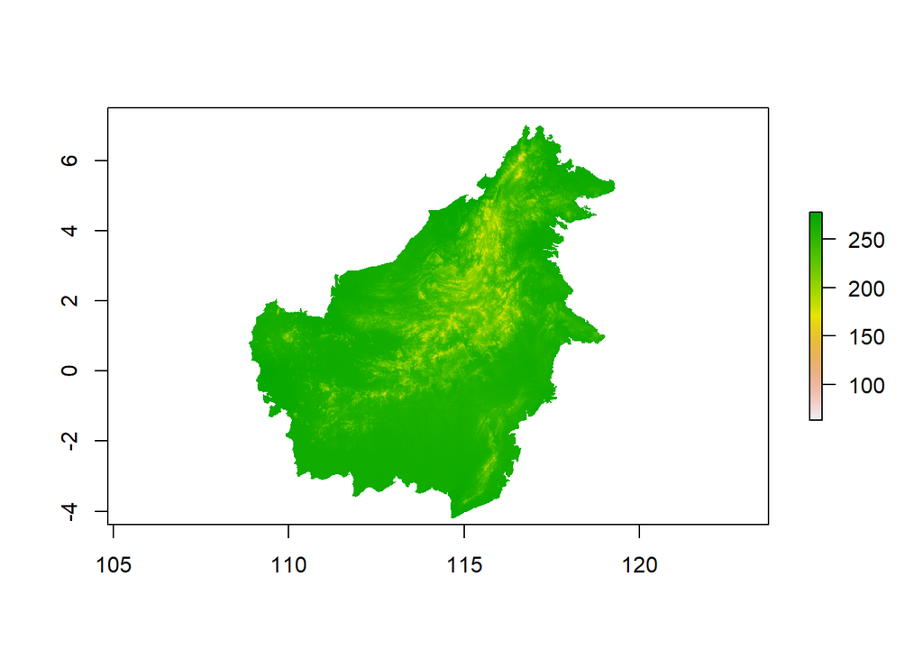

```r
# base plot
plot(x = ras1)
```

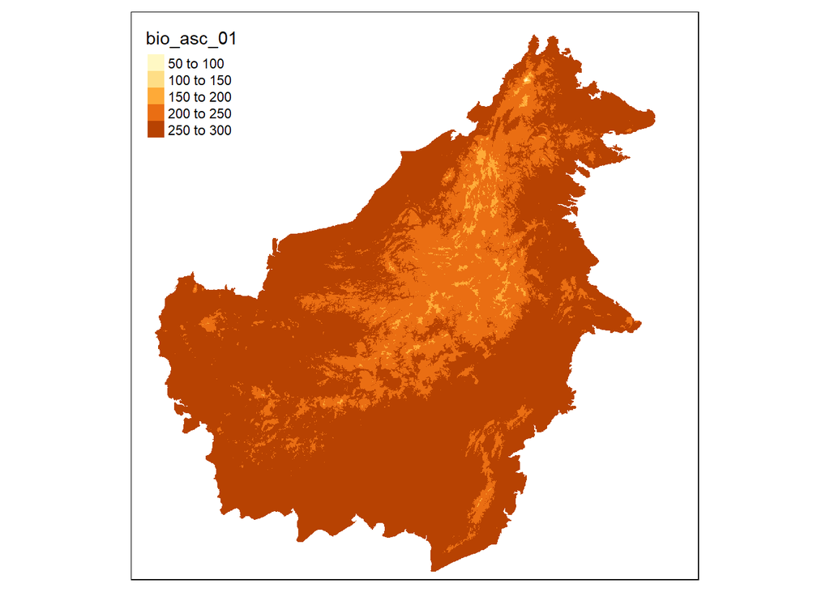

```r
# static plot
tmap_mode(mode = "plot")
tm_shape(shp = ras1) + tm_raster()
```

```r
# interactive plot
tmap_mode(mode = "view")
tm_shape(shp = ras1) + tm_raster()
```

[interactive chart not shown]

## Before we start: clip a small area

```r
extent(x = ras1)
```

```
## class       : Extent
## xmin        : 108.3341
## xmax        : 120.1925
## ymin        : -4.374013
## ymax        : 7.500988
```

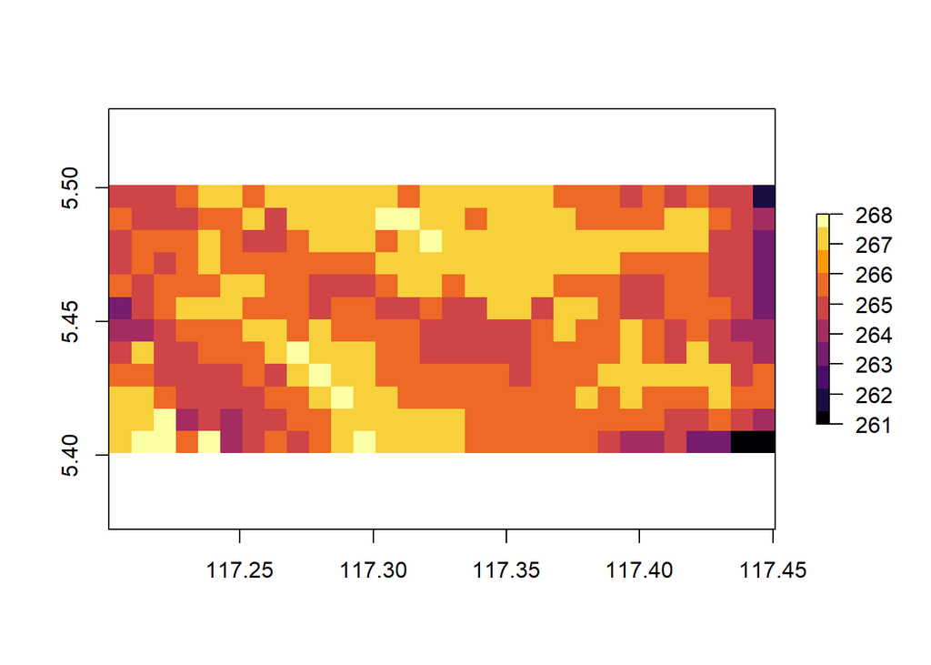

```r
clip_extent <- extent(117.2, 117.45, 5.4, 5.5)
ras1_cr <- crop(x = ras1, y = clip_extent)
plot(ras1_cr, col= inferno(10))
```

## working with the ‘RasterLayer’ class

```r
#Have a look at the internal data structure
#of the raster object:
ras1_cr # str(ras1_cr) # attributes(ras1_cr)
```

```
## class       : RasterLayer
## dimensions  : 12, 30, 360  (nrow, ncol, ncell)
## resolution  : 0.008333334, 0.008333334  (x, y)
## extent      : 117.2008, 117.4508, 5.400988, 5.500988  (xmin, xmax, ymin, ymax)
## coord. ref. : +init=epsg:4326 +proj=longlat +datum=WGS84 +no_defs +ellps=WGS84 +towgs84=0,0,0
## data source : in memory
## names       : bio_asc_01
## values      : 261, 268  (min, max)
```

```r
#Retrieve internal data and access single bits of information
bbox(obj = ras1_cr)
```

```
##           min        max
## s1 117.200790 117.450790
## s2   5.400988   5.500988
```

```r
ras1_cr@extent@xmin
```

```
## [1] 117.2008
```

```r
   # xmin(ras1_cr) # xmin(extent(ras1))
   # ras1_cr@extent # extent(ras1_cr) # attr(ras1_cr,'extent')
ras1_cr@ncols        # ncol(ras1_cr) !n.b. cols vs. col!
```

```
## [1] 30
```

```r
ras1_cr@data@values  # values(ras1_cr)
```

```
##   [1] 265 265 265 266 267 267 266 267 267 267 267 267 267 266 267 267 267
##  [18] 267 267 267 266 266 266 265 266 265 266 265 265 262 266 265 265 265
##  [35] 266 266 267 265 267 267 267 267 268 268 267 267 266 267 267 267 267
##  [52] 266 266 266 266 267 267 266 265 264 265 266 266 266 267 266 265 265
##  [69] 266 267 267 267 266 267 268 267 267 267 267 267 267 267 267 267 267
##  [86] 267 267 265 265 263 265 266 265 266 267 266 266 266 266 266 266 266
## [103] 267 267 267 267 267 267 267 267 267 267 267 266 266 266 266 265 265
## [120] 263 266 265 266 266 266 267 267 266 266 265 265 265 266 267 267 266
## [137] 267 267 267 267 266 266 266 265 265 266 266 265 265 263 263 265 266
## [154] 267 267 267 266 266 266 265 266 266 265 265 266 265 265 267 267 265
## [171] 267 267 266 265 265 266 266 266 265 263 264 264 265 266 266 266 267
## [188] 267 266 267 266 266 266 266 265 265 265 265 265 266 267 266 266 267
## [205] 266 265 266 265 264 264 265 267 265 265 266 266 266 267 268 267 267
## [222] 267 266 266 265 265 265 265 265 266 266 266 266 267 266 265 267 265
## [239] 265 264 266 266 265 265 265 265 266 265 267 268 267 267 266 266 266
## [256] 266 266 266 265 266 266 266 267 267 267 267 267 267 265 266 267 267
## [273] 266 265 265 265 265 266 266 267 268 267 267 266 266 266 266 266 266
## [290] 266 266 267 266 267 266 266 266 267 266 266 267 267 268 264 265 264
## [307] 265 265 266 266 267 267 267 267 267 267 266 266 266 266 266 266 266
## [324] 266 266 265 265 266 265 264 267 268 268 266 268 264 265 266 265 266
## [341] 267 268 267 267 267 267 266 266 266 266 266 266 265 264 264 265 263
## [358] 263 261 261
```

```r
ras1_cr@crs
```

```
## CRS arguments:
##  +init=epsg:4326 +proj=longlat +datum=WGS84 +no_defs +ellps=WGS84
## +towgs84=0,0,0
```

```r
   # crs(ras1_cr) # projection(ras1_cr) !=CRS(ras1_cr)

# crs = coordinate reference system defined
# CRS creates projection and takes args for crs!
# e.g. CRS("+proj=longlat +datum=WGS84")
```

```r
#Retrieve internal data cont.:
nrow(x = ras1_cr) # ncol(ras1_cr) # ncell(ras1_cr)
```

```
## [1] 12
```

```r
dim(x = ras1_cr)  # 12 rows, 30 columns, 1 z-dimension
```

```
## [1] 12 30  1
```

```r
res(x = ras1_cr)  # resolution = cell size
```

```
## [1] 0.008333334 0.008333334
```

```r
head(x = coordinates(obj = ras1_cr), n = 10) # command from package 'sp'
```

```
##              x        y
##  [1,] 117.2050 5.496821
##  [2,] 117.2133 5.496821
##  [3,] 117.2216 5.496821
##  [4,] 117.2300 5.496821
##  [5,] 117.2383 5.496821
##  [6,] 117.2466 5.496821
##  [7,] 117.2550 5.496821
##  [8,] 117.2633 5.496821
##  [9,] 117.2716 5.496821
## [10,] 117.2800 5.496821
```

## Visualising (plotting) raster data

Difference between *plot* and *image*

### plot

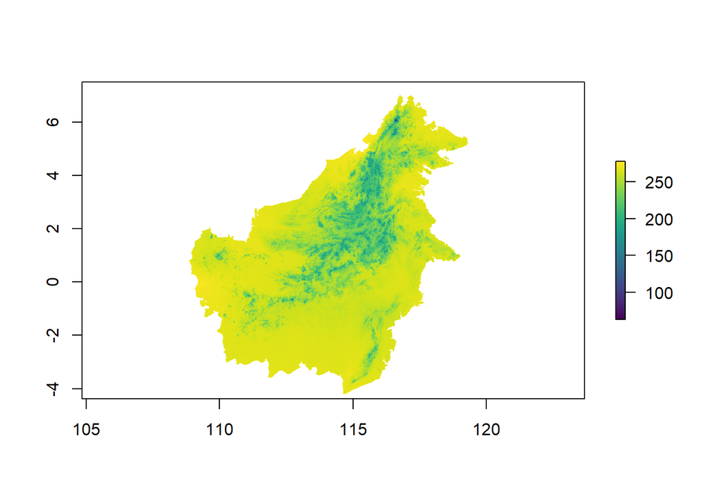

```r
plot(x = ras1, col=viridis(256))
```

```r
#plot(ras1_cr)
```

### Image (raster)

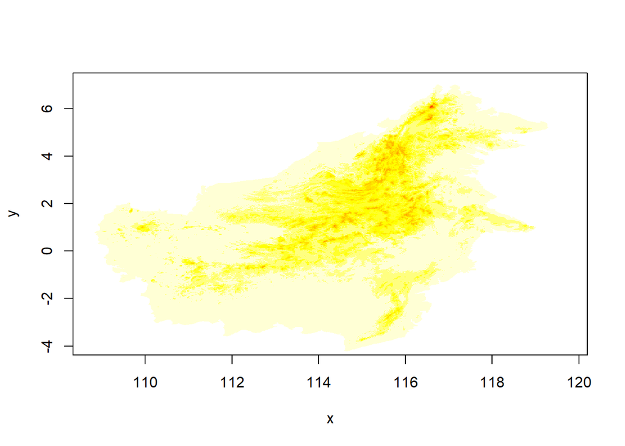

```r
#- if you use *image*, the proportions will be changed
image(x = ras1)
```

```r
# image(ras1_cr)
```

,,,,,,,,,,,,,,,,,,,,,,,,,,,,,,,,,,,,,,,,,,,,,,,,,,,,,,,,,,,,,,,,,,,  
### Interactive plot

```r
tmap_mode("view")
(i.m <- tm_shape(ras1) +
  tm_raster(palette = "viridis",  title = "Mean annual temp"))
```

[interactive chart not shown]

```r
save_tmap(i.m, paste0(output_wd,"/BorneoMAT_4326.html"))
```

You can also use this package to create high quality plots for your publications.

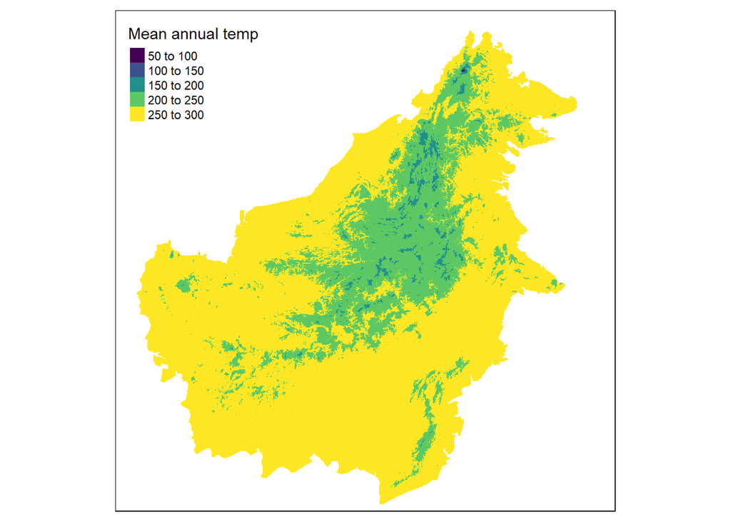

```r
tmap_mode("plot")
(m <- tm_shape(ras1) +
  tm_raster(palette = "viridis",  title = "Mean annual temp"))
```

```r
save_tmap(m, paste0(output_wd,"/BorneoMap_4326.png"), units = "mm", width = 70, height = 70, dpi = 150 )
```

### Terrain computation - Create a hillshade (3D look)

- simulates a 3D surface
- computes shaded relief values for a raster surface

```r
slope <- terrain(x = ras24, opt = "slope",
                    unit = "radians", neighbors = 8)
aspect <- terrain(x = ras24, opt = "aspect",
                     unit = "radians", neighbors = 8)
Bor_hs <- hillShade(slope, aspect, angle = 45,
                      direction = 270)
```

Plot the hillshade

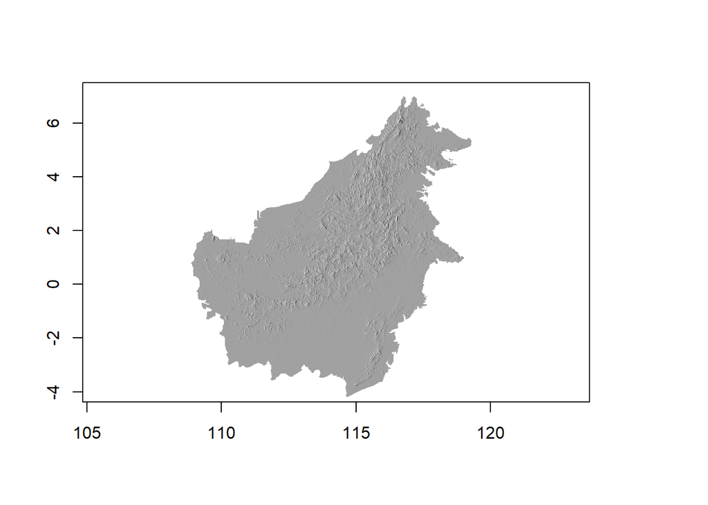

```r
plot(Bor_hs, col=grey(0:100/100), legend=FALSE)
```

and add colors on top: alpha value gives semi-transparency

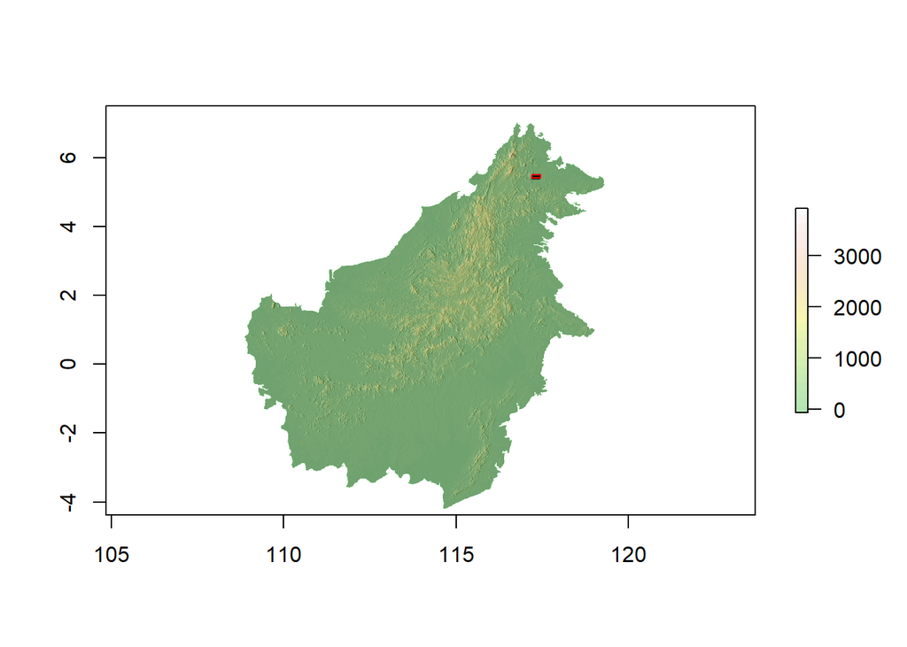

```r
plot(Bor_hs, col=grey(0:100/100), legend=FALSE)
plot(ras24, col=terrain.colors(25,alpha=0.3),add=T)
points(coordinates(ras1_cr),cex=0.1,pch='+')
plot(extent(ras1_cr),add=T, col='red')
```

,,,,,,,,,,,,,,,,,,,,,,,,,,,,,,,,,,,,,,,,,,,,,,,,,,,,,,,,,,,,,,,,,,,,,,,,,,,,,,,,,,,,,,,,,,,,,,,,,,,,,,,,,,,,,,,,

### perspective: 3D plot

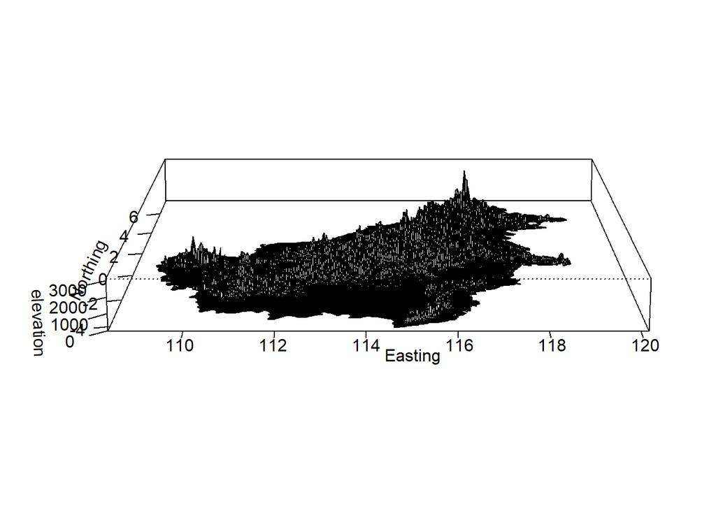

```r
#- Cool 3D plots with rgl library, e.g. 'rgl.surface'
#- Why is it so spiny??? Check units!
persp(x = ras24, xlab = "Easting", ylab = "Northing",
      zlab = "elevation", r = 5, d = 1.5, expand = 0.1,
      ticktype = "detailed")
```

## Raster projection

Project the Grid (the small one!!!)

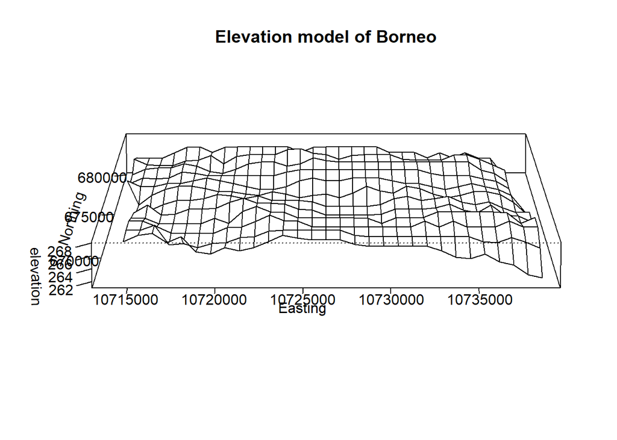

```r
proj_moll=CRS("+proj=moll +lat_0=65 +lon_0=10") # Mollweide
Bor_dem_moll <-projectRaster(ras1_cr,crs=proj_moll)
persp(Bor_dem_moll, xlab="Easting", ylab="Northing",
      zlab="elevation", main="Elevation model of Borneo",
      r=1, d=5.5, expand=0.1, ticktype="detailed")
```

## Raster Stacks - similar to geodatabase

### Append files

```r
# A raster stack is a collection of RasterLayer objects
# with the same spatial extent and resolution

files.full <- list.files(path = maps_wd, pattern = '.asc$',
                         full.names = TRUE )
files.full[1:2]
```

```
## [1] "c:/Users/kramer/Dropbox/_Geodata_Borneo/BaseMaps/bias1.asc"
## [2] "c:/Users/kramer/Dropbox/_Geodata_Borneo/BaseMaps/bias3.asc"
```

```r
files.rel <- list.files(path = maps_wd, pattern = '.asc$',
                        full.names = FALSE )
files.rel[1:2]
```

```
## [1] "bias1.asc" "bias3.asc"
```

### Working with stacks

```r
#- We can assign each single raster a projection with just one command!
predictors <- stack(x = files.full[c(9, 12, 22, 24)])
projection(x = predictors) # crs(predictors)
```

```
## [1] NA
```

```r
projection(x = predictors) <- CRS(projargs = "+proj=longlat +datum=WGS84")
```

A raster stack contains the single raster layers in a list

```r
predictors@layers # this is a list! Address single layers with [[ ]]
```

```
## [[1]]
## class       : RasterLayer
## dimensions  : 1425, 1423, 2027775  (nrow, ncol, ncell)
## resolution  : 0.008333334, 0.008333334  (x, y)
## extent      : 108.3341, 120.1925, -4.374013, 7.500988  (xmin, xmax, ymin, ymax)
## coord. ref. : +proj=longlat +datum=WGS84 +ellps=WGS84 +towgs84=0,0,0
## data source : c:/Users/kramer/Dropbox/_Geodata_Borneo/BaseMaps/bio_asc_07.asc
## names       : bio_asc_07
##
##
## [[2]]
## class       : RasterLayer
## dimensions  : 1425, 1423, 2027775  (nrow, ncol, ncell)
## resolution  : 0.008333334, 0.008333334  (x, y)
## extent      : 108.3341, 120.1925, -4.374013, 7.500988  (xmin, xmax, ymin, ymax)
## coord. ref. : +proj=longlat +datum=WGS84 +ellps=WGS84 +towgs84=0,0,0
## data source : c:/Users/kramer/Dropbox/_Geodata_Borneo/BaseMaps/bio_asc_10.asc
## names       : bio_asc_10
##
##
## [[3]]
## class       : RasterLayer
## dimensions  : 1425, 1423, 2027775  (nrow, ncol, ncell)
## resolution  : 0.008333334, 0.008333334  (x, y)
## extent      : 108.3341, 120.1925, -4.374013, 7.500988  (xmin, xmax, ymin, ymax)
## coord. ref. : +proj=longlat +datum=WGS84 +ellps=WGS84 +towgs84=0,0,0
## data source : c:/Users/kramer/Dropbox/_Geodata_Borneo/BaseMaps/bio_asc_21.asc
## names       : bio_asc_21
##
##
## [[4]]
## class       : RasterLayer
## dimensions  : 1425, 1423, 2027775  (nrow, ncol, ncell)
## resolution  : 0.008333334, 0.008333334  (x, y)
## extent      : 108.3341, 120.1925, -4.374013, 7.500988  (xmin, xmax, ymin, ymax)
## coord. ref. : +proj=longlat +datum=WGS84 +ellps=WGS84 +towgs84=0,0,0
## data source : c:/Users/kramer/Dropbox/_Geodata_Borneo/BaseMaps/bio_asc_24.asc
## names       : bio_asc_24
## values      : -2147483648, 2147483647  (min, max)
```

```r
#- Extract information from all rasters in one command
# cellStats(predictors, 'mean')
round(x = cellStats(x = predictors, stat = 'mean'), digits = 2)
```

```
## bio_asc_07 bio_asc_10 bio_asc_21 bio_asc_24
##      88.61     258.38       0.02     251.75
```

### plot stack with base plot

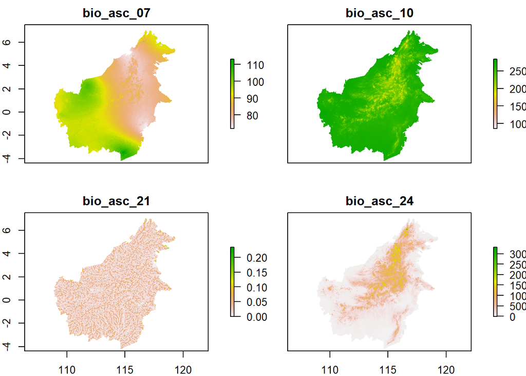

```r
plot(x = predictors)
```

### plot stack with tmap

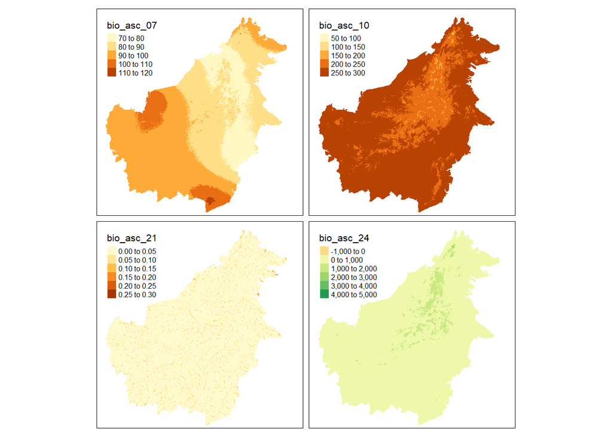

```r
tmap_mode(mode = "plot")
tm_shape(shp = predictors) + tm_raster()
```

```r
tmap_mode(mode = "view")
tm_shape(shp = predictors) + tm_raster()
```

[interactive chart not shown]

### Bw-plot from raster stack

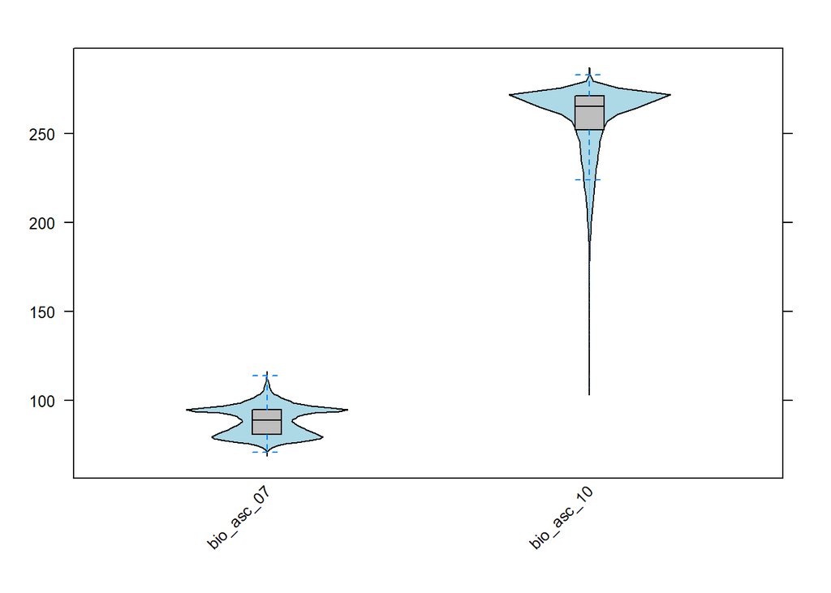

```r
bwplot(x = predictors[[c(1, 2)]]) # bwplot(predictors)
```

```r
# n.b. double [[ ]] because stack is a list of spatial rasters
```

## Data export

### Save the hillshade raster (not the plot…)

```r
#- define the workspace where to save - but remember that you change the working directory with that!
#- Better: store path within the file name (see point data example)
setwd(dir = output_wd)
#- save the data
writeRaster(x = Bor_hs,
            filename = "hillshade.asc",
            format = "ascii",
            overwrite = TRUE,
            NAflag = -9999)
#- set back working directory
setwd(dir = work_wd)
```

## Manipulating rasters

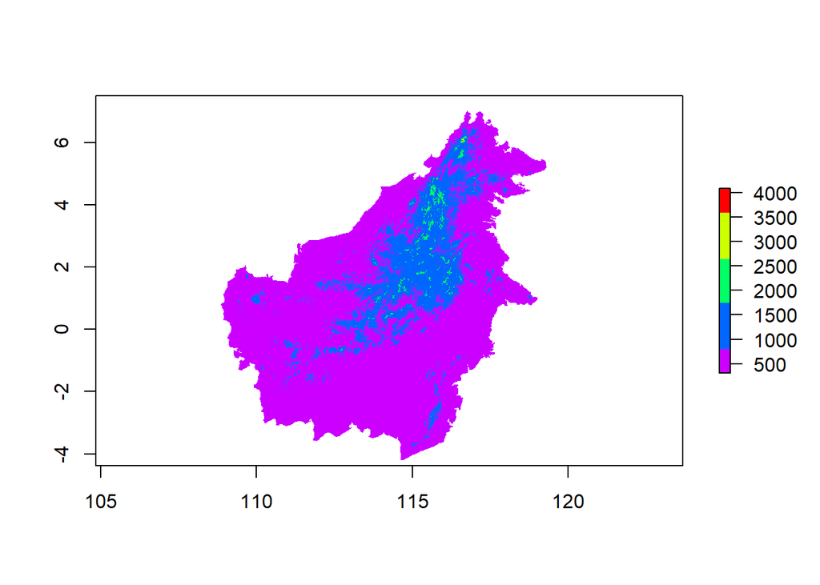

```r
vignette(topic = 'Raster') #vignette(package='raster')
#Do any kind of raster algebra
new_ras <- ras1 + ras24 + 100
plot(x = new_ras, col = rev(rainbow(5)))
```

## Change and query raster values

```r
# convert ras1 to degree Celsius units (divide by 10)
range(values(ras1), na.rm = TRUE)
```

```
## [1]  63 278
```

```r
mean.t.c <- ras1 / 10
range(values(mean.t.c), na.rm = TRUE)
```

```
## [1]  6.3 27.8
```

```r
# find areas with mean annual temp >= 25 deg C
mean.t.c.25 <- mean.t.c >= 25
```

Have a look at the binary plot

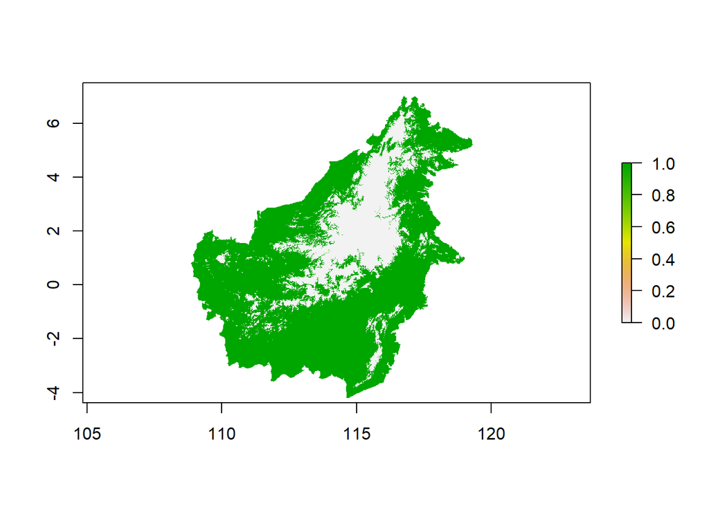

```r
plot(x = mean.t.c.25)
```

## Accessing cell values of a raster I

Remember the function **extract()**

```r
cells <- cellFromRowCol(object = ras1_cr, row = 5, col = 1:3)
cells    #gives cell ID number!!!
```

```
## [1] 121 122 123
```

```r
extract(x = ras1_cr, y = cells) # gives cell values!
```

```
## [1] 266 265 266
```

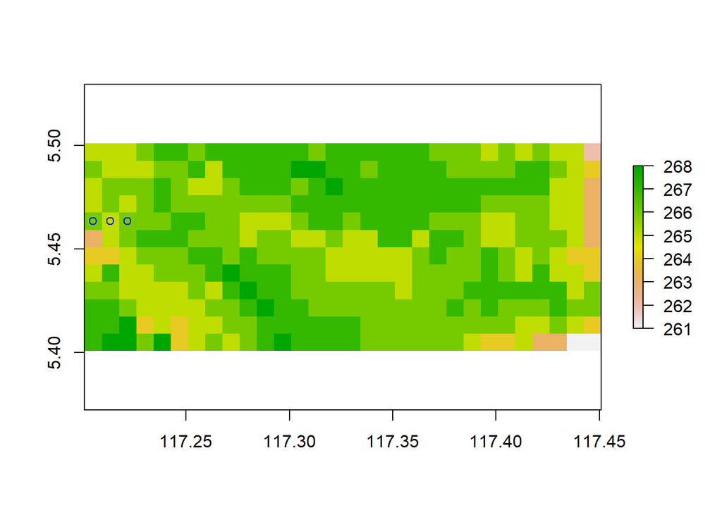

```r
plot(x = ras1_cr)
points(x = coordinates(obj = ras1_cr)[cells,], col = 'blue')
```

##### extract rastervalues from all rasters at once

This is very important if you want to create your master table, i.e. based on the xy-coordinates of your species sighting, you could extract the important environmental predictors at that location.

```r
pred_dat <-   extract(predictors, cells)
pred_dat
```

```
##      bio_asc_07 bio_asc_10 bio_asc_21 bio_asc_24
## [1,]         NA         NA         NA         NA
## [2,]         NA         NA         NA         NA
## [3,]         NA         NA         NA         NA
```

```r
test <- data.frame(cells,pred_dat)
test
```

```
##   cells bio_asc_07 bio_asc_10 bio_asc_21 bio_asc_24
## 1   121         NA         NA         NA         NA
## 2   122         NA         NA         NA         NA
## 3   123         NA         NA         NA         NA
```

# Working with shapefiles

## Import shapefiles (polygons and lines)

```r
#- you need to install the package **sf** for this command.
#- dsn sets wd! no need to setwd().
Borneo_shp <- st_read(dsn = maps_wd,
                      layer = "borneo_admin",
                      stringsAsFactors = FALSE)[, c(1:3, 5, 7, 17, 18)]
PA_shp <-  st_read(dsn = maps_wd,
                   layer = "Bor_PA",
                   stringsAsFactors = FALSE)[, c(1:4)]
River_shp <- st_read(dsn = maps_wd,
                     layer = "sn_100000",
                     stringsAsFactors = FALSE)
#,,,,,,,,,,,,,,,,,,,,,,,,,,,,,,,,,,,,,,,,,,,,,,,,,,,,,,,,,
## the 'old' sp package would work with that command:
Admin_shp <- readOGR(dsn=maps_wd, layer="borneo_admin",
              stringsAsFactors=FALSE)[,c(1:3,5,7,17,18)]
## transformations
Admin_sf <- as(Admin_shp, "sf") ## from sp object to sf object
Admin_sp <- as(Admin_sf, "Spatial") ## from sf to sp object
```

## Retrieving general information of spatial layer

```r
#Please note the similarity to accessing info from rasters.
str(object = extent(PA_shp))
```

```
## Formal class 'Extent' [package "raster"] with 4 slots
##   ..@ xmin: Named num 109
##   .. ..- attr(*, "names")= chr "xmin"
##   ..@ xmax: Named num 120
##   .. ..- attr(*, "names")= chr "xmax"
##   ..@ ymin: Named num -4.18
##   .. ..- attr(*, "names")= chr "ymin"
##   ..@ ymax: Named num 9.91
##   .. ..- attr(*, "names")= chr "ymax"
```

```r
extent(PA_shp)@xmin
```

```
##     xmin
## 108.5969
```

```r
names(x = PA_shp) #returns column names of a.t.
```

```
## [1] "SITE_ID"  "NAME_ENG" "COUNTRY"  "SUB_NAT"  "geometry"
```

## Retrieving summary for each column of attribute table [a.t.]

```r
summary(object = PA_shp)
```

```
##     SITE_ID         NAME_ENG           COUNTRY            SUB_NAT
##  Min.   :   783   Length:255         Length:255         Length:255
##  1st Qu.:  3844   Class :character   Class :character   Class :character
##  Median :  9842   Mode  :character   Mode  :character   Mode  :character
##  Mean   : 45309
##  3rd Qu.: 19582
##  Max.   :901238
##           geometry
##  MULTIPOLYGON :255
##  epsg:4326    :  0
##  +proj=long...:  0
##
##
##
```

```r
str(object = PA_shp)
```

```
## Classes 'sf' and 'data.frame':   255 obs. of  5 variables:
##  $ SITE_ID : int  785 787 791 795 1300 783 784 786 788 789 ...
##  $ NAME_ENG: chr  "Kinabalu" "Mulu" "Niah" "Tawau Hill Park" ...
##  $ COUNTRY : chr  "Malaysia" "Malaysia" "Malaysia" "Malaysia" ...
##  $ SUB_NAT : chr  "Sabah" "Sarawak" "Sarawak" "Sabah" ...
##  $ geometry:sfc_MULTIPOLYGON of length 255; first list element: List of 1
##   ..$ :List of 1
##   .. ..$ : num [1:322, 1:2] 117 117 117 117 117 ...
##   ..- attr(*, "class")= chr  "XY" "MULTIPOLYGON" "sfg"
##  - attr(*, "sf_column")= chr "geometry"
##  - attr(*, "agr")= Factor w/ 3 levels "constant","aggregate",..: NA NA NA NA
##   ..- attr(*, "names")= chr  "SITE_ID" "NAME_ENG" "COUNTRY" "SUB_NAT"
```

```r
PA_shp
```

```
## Simple feature collection with 255 features and 4 fields
## geometry type:  MULTIPOLYGON
## dimension:      XY
## bbox:           xmin: 108.5969 ymin: -4.18356 xmax: 119.6176 ymax: 9.911229
## epsg (SRID):    4326
## proj4string:    +proj=longlat +datum=WGS84 +no_defs
## First 10 features:
##    SITE_ID        NAME_ENG  COUNTRY SUB_NAT                       geometry
## 1      785        Kinabalu Malaysia   Sabah MULTIPOLYGON (((116.5986 6....
## 2      787            Mulu Malaysia Sarawak MULTIPOLYGON (((114.9032 4....
## 3      791            Niah Malaysia Sarawak MULTIPOLYGON (((113.7946 3....
## 4      795 Tawau Hill Park Malaysia   Sabah MULTIPOLYGON (((118.0382 4....
## 5     1300  Lanjak-Entimau Malaysia Sarawak MULTIPOLYGON (((112.2056 1....
## 6      783        Semporna Malaysia   Sabah MULTIPOLYGON (((118.7811 4....
## 7      784        Samunsam Malaysia Sarawak MULTIPOLYGON (((109.6633 1....
## 8      786       Similajau Malaysia Sarawak MULTIPOLYGON (((113.1807 3....
## 9      788           Klias Malaysia   Sabah MULTIPOLYGON (((115.6748 5....
## 10     789      Pulau Tiga Malaysia   Sabah MULTIPOLYGON (((115.6722 5....
```

```r
attributes(x = PA_shp)
```

```
## $names
## [1] "SITE_ID"  "NAME_ENG" "COUNTRY"  "SUB_NAT"  "geometry"
##
## $row.names
##   [1]   1   2   3   4   5   6   7   8   9  10  11  12  13  14  15  16  17
##  [18]  18  19  20  21  22  23  24  25  26  27  28  29  30  31  32  33  34
##  [35]  35  36  37  38  39  40  41  42  43  44  45  46  47  48  49  50  51
##  [52]  52  53  54  55  56  57  58  59  60  61  62  63  64  65  66  67  68
##  [69]  69  70  71  72  73  74  75  76  77  78  79  80  81  82  83  84  85
##  [86]  86  87  88  89  90  91  92  93  94  95  96  97  98  99 100 101 102
## [103] 103 104 105 106 107 108 109 110 111 112 113 114 115 116 117 118 119
## [120] 120 121 122 123 124 125 126 127 128 129 130 131 132 133 134 135 136
## [137] 137 138 139 140 141 142 143 144 145 146 147 148 149 150 151 152 153
## [154] 154 155 156 157 158 159 160 161 162 163 164 165 166 167 168 169 170
## [171] 171 172 173 174 175 176 177 178 179 180 181 182 183 184 185 186 187
## [188] 188 189 190 191 192 193 194 195 196 197 198 199 200 201 202 203 204
## [205] 205 206 207 208 209 210 211 212 213 214 215 216 217 218 219 220 221
## [222] 222 223 224 225 226 227 228 229 230 231 232 233 234 235 236 237 238
## [239] 239 240 241 242 243 244 245 246 247 248 249 250 251 252 253 254 255
##
## $class
## [1] "sf"         "data.frame"
##
## $sf_column
## [1] "geometry"
##
## $agr
##  SITE_ID NAME_ENG  COUNTRY  SUB_NAT
##     <NA>     <NA>     <NA>     <NA>
## Levels: constant aggregate identity
```

### Retrieving information of a.t. I

```r
head(x = PA_shp)
```

```
## Simple feature collection with 6 features and 4 fields
## geometry type:  MULTIPOLYGON
## dimension:      XY
## bbox:           xmin: 111.8754 ymin: 1.32105 xmax: 118.7899 ymax: 6.4952
## epsg (SRID):    4326
## proj4string:    +proj=longlat +datum=WGS84 +no_defs
##   SITE_ID        NAME_ENG  COUNTRY SUB_NAT                       geometry
## 1     785        Kinabalu Malaysia   Sabah MULTIPOLYGON (((116.5986 6....
## 2     787            Mulu Malaysia Sarawak MULTIPOLYGON (((114.9032 4....
## 3     791            Niah Malaysia Sarawak MULTIPOLYGON (((113.7946 3....
## 4     795 Tawau Hill Park Malaysia   Sabah MULTIPOLYGON (((118.0382 4....
## 5    1300  Lanjak-Entimau Malaysia Sarawak MULTIPOLYGON (((112.2056 1....
## 6     783        Semporna Malaysia   Sabah MULTIPOLYGON (((118.7811 4....
```

```r
tail(x = PA_shp)
```

```
## Simple feature collection with 6 features and 4 fields
## geometry type:  MULTIPOLYGON
## dimension:      XY
## bbox:           xmin: 111.4107 ymin: -3.035619 xmax: 118.2907 ymax: 6.4952
## epsg (SRID):    4326
## proj4string:    +proj=longlat +datum=WGS84 +no_defs
##     SITE_ID                NAME_ENG           COUNTRY SUB_NAT
## 250  317300        Maganting Island          Malaysia   Sabah
## 251  317301                 Bod Tai          Malaysia   Sabah
## 252  342562 Tanjung Penghujan NR/RP         Indonesia    <NA>
## 253  901236          Tasek Merimbun Brunei Darussalam    <NA>
## 254  901237  Kinabalu National Park          Malaysia    <NA>
## 255  901238      Mulu National Park          Malaysia    <NA>
##                           geometry
## 250 MULTIPOLYGON (((118.2853 4....
## 251 MULTIPOLYGON (((118.2181 5....
## 252 MULTIPOLYGON (((111.443 -2....
## 253 MULTIPOLYGON (((114.7236 4....
## 254 MULTIPOLYGON (((116.5986 6....
## 255 MULTIPOLYGON (((114.9032 4....
```

### Retrieving information of a.t. II

```r
PA_shp[1, ] #returns first entry (row) of all 4 columns
```

```
## Simple feature collection with 1 feature and 4 fields
## geometry type:  MULTIPOLYGON
## dimension:      XY
## bbox:           xmin: 116.4638 ymin: 5.99952 xmax: 116.7631 ymax: 6.4952
## epsg (SRID):    4326
## proj4string:    +proj=longlat +datum=WGS84 +no_defs
##   SITE_ID NAME_ENG  COUNTRY SUB_NAT                       geometry
## 1     785 Kinabalu Malaysia   Sabah MULTIPOLYGON (((116.5986 6....
```

### Retrieving information of a.t. III

```r
PA_shp[, 2] # returns summary of col only!
```

```
## Simple feature collection with 255 features and 1 field
## geometry type:  MULTIPOLYGON
## dimension:      XY
## bbox:           xmin: 108.5969 ymin: -4.18356 xmax: 119.6176 ymax: 9.911229
## epsg (SRID):    4326
## proj4string:    +proj=longlat +datum=WGS84 +no_defs
## First 10 features:
##           NAME_ENG                       geometry
## 1         Kinabalu MULTIPOLYGON (((116.5986 6....
## 2             Mulu MULTIPOLYGON (((114.9032 4....
## 3             Niah MULTIPOLYGON (((113.7946 3....
## 4  Tawau Hill Park MULTIPOLYGON (((118.0382 4....
## 5   Lanjak-Entimau MULTIPOLYGON (((112.2056 1....
## 6         Semporna MULTIPOLYGON (((118.7811 4....
## 7         Samunsam MULTIPOLYGON (((109.6633 1....
## 8        Similajau MULTIPOLYGON (((113.1807 3....
## 9            Klias MULTIPOLYGON (((115.6748 5....
## 10      Pulau Tiga MULTIPOLYGON (((115.6722 5....
```

```r
PA_shp$NAME_ENG #returns a list
```

```
##   [1] "Kinabalu"
##   [2] "Mulu"
##   [3] "Niah"
##   [4] "Tawau Hill Park"
##   [5] "Lanjak-Entimau"
##   [6] "Semporna"
##   [7] "Samunsam"
##   [8] "Similajau"
##   [9] "Klias"
##  [10] "Pulau Tiga"
##  [11] "Tunku Abdul Rahman"
##  [12] "Bako"
##  [13] "Pulau Penyu (Turtle Islands)"
##  [14] "Kutai"
##  [15] "Sungai Kayan Sungai Mentarang"
```

[output cut: 240 more lines]

```r
head(x = PA_shp$NAME_ENG)
```

```
## [1] "Kinabalu"        "Mulu"            "Niah"            "Tawau Hill Park"
## [5] "Lanjak-Entimau"  "Semporna"
```

```r
# [1] "Kinabalu"
# [2] "Mulu"
# [3] "Niah"

PA_shp[1, 1] # = PA_shp$SITE_ID[1]
```

```
## Simple feature collection with 1 feature and 1 field
## geometry type:  MULTIPOLYGON
## dimension:      XY
## bbox:           xmin: 116.4638 ymin: 5.99952 xmax: 116.7631 ymax: 6.4952
## epsg (SRID):    4326
## proj4string:    +proj=longlat +datum=WGS84 +no_defs
##   SITE_ID                       geometry
## 1     785 MULTIPOLYGON (((116.5986 6....
```

```r
PA_shp[2, 3] # = PA_shp$COUNTRY[2]
```

```
## Simple feature collection with 1 feature and 1 field
## geometry type:  MULTIPOLYGON
## dimension:      XY
## bbox:           xmin: 114.7777 ymin: 3.9186 xmax: 114.9945 ymax: 4.28586
## epsg (SRID):    4326
## proj4string:    +proj=longlat +datum=WGS84 +no_defs
##    COUNTRY                       geometry
## 2 Malaysia MULTIPOLYGON (((114.9032 4....
```

```r
which(x = PA_shp$COUNTRY == 'Malaysia')
```

```
##   [1]   1   2   3   4   5   6   7   8   9  10  11  12  13  26  27  28  29
##  [18]  30  31  32  33  34  35  36  37  38  39  40  41  42  43  44  45  46
##  [35]  47  48  49  50  51  52  53  54  55  56  63  64  65  66  67  68  69
##  [52]  70  71  72  73  74  75  76  77  80  81 101 102 103 104 113 114 115
##  [69] 116 117 118 119 120 121 122 123 124 125 126 127 128 129 130 131 132
##  [86] 133 134 135 136 137 138 139 140 141 142 143 144 145 146 147 148 149
## [103] 150 151 152 153 154 155 156 157 158 159 161 162 163 164 165 166 167
## [120] 169 170 171 172 185 186 187 190 191 192 193 194 195 196 221 222 223
## [137] 224 225 226 227 228 230 233 237 238 239 240 241 249 250 251 254 255
```

### Plotting the shapefile

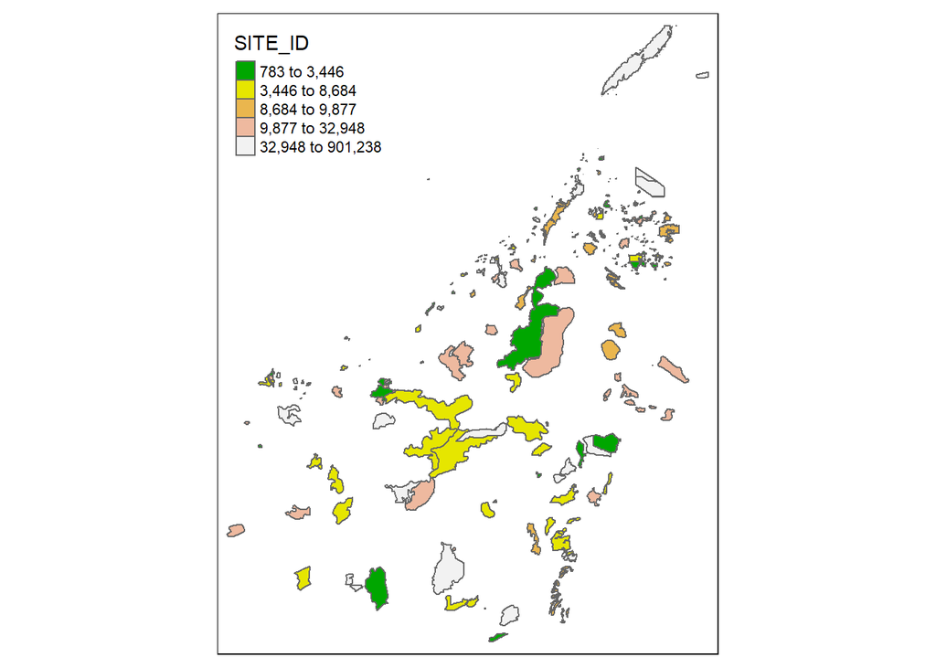

```r
tmap_mode(mode = "plot")
tm_shape(shp = PA_shp[, 1]) + tm_polygons(col = "SITE_ID",
                                          palette = grDevices::terrain.colors(5),
                                          style = "quantile" # color schema divided by quantiles
                                          )
```

### Plot a detail on the map

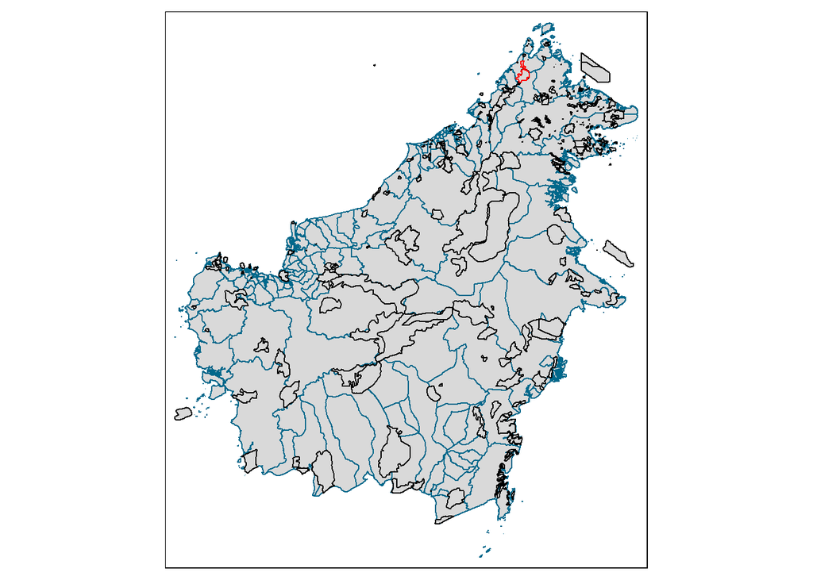

```r
tmap_mode(mode = "plot")
tm_shape(shp = Borneo_shp) + tm_polygons(border.col = "deepskyblue4") +
  tm_shape(PA_shp[,1]) + tm_polygons(border.col = "black") +
  tm_shape(PA_shp[1, ]) + tm_polygons(border.col = "red")
```

## Geospatial calculation and projection I

### command *st_area*

```r
st_area(x = Borneo_shp)
```

```
## Units: [m^2]
##   [1]  7617642655  1233165212   483936285  6101403252  1461721994
##   [6]  2942390535  2248154794  1165236763  2773393190  1488754822
##  [11]  1710460979  3636329225 17808524499  1363752909   368058339
##  [16]  1849387894   460370881  1295098658  8332431646  5925679102
##  [21]  2257766354  1178776353   218871372 19494354707  2584685108
##  [26]   941677750 19559971656  1922998073  1509056913   590928874
##  [31]  7087539550   301350640  2075011439   403663636   287980997
##  [36]   927193989  1652156667   430995362  2164993212 14065236329
##  [41]   882055150  2896245707   862820674   234449088  1414534941
##  [46]  1369966619   527879865  1149476183   371126807   920847320
##  [51]   883596604  2390382587  3171300454  1692662676  2815953691
##  [56]   309343004   516013120   972279336   781793406   185304151
##  [61]   327067608   357039904   434319270   614643147   752405608
##  [66]   528071905   398235793  1825037091  2541183276   359700772
```

[output cut: 18 more lines]

### Spatial transformation

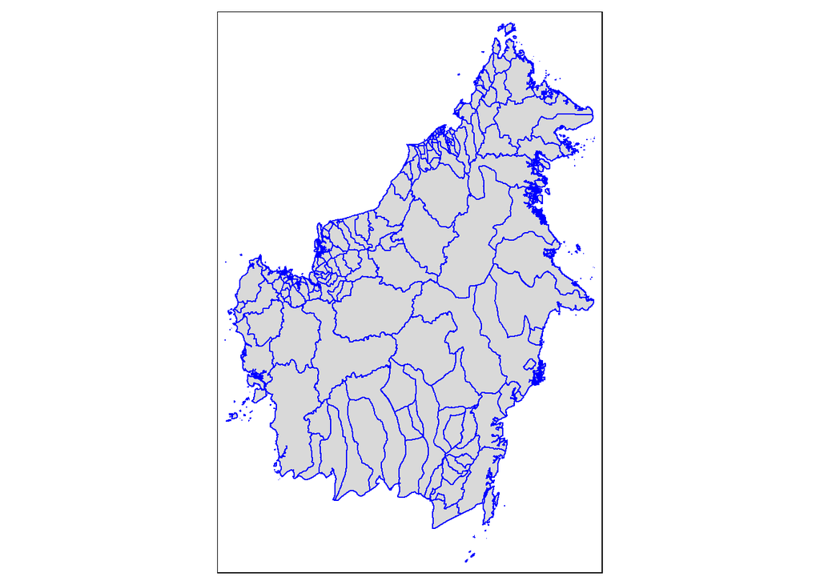

```r
Borneo_shp_moll <-  st_transform(Borneo_shp, c("+proj=moll +datum=WGS84"))

tmap_mode(mode = "plot")
tm_shape(shp = Borneo_shp_moll) + tm_polygons(border.col = "blue") #do you see the difference?
```

```r
st_area(x = Borneo_shp_moll) # units?
```

```
## Units: [m^2]
##   [1]  7666715202  1241315346   487129643  6141990607  1471302821
##   [6]  2961802507  2263029229  1172993311  2791833541  1498591017
##  [11]  1721789306  3660423426 17928009141  1372719968   370483904
##  [16]  1861538283   463417217  1303565563  8387302962  5965126824
##  [21]  2272762478  1186542232   220344969 19624768031  2602052029
##  [26]   948010345 19691304201  1935913456  1519119254   594900279
##  [31]  7135006724   303399175  2088937303   406358163   289920412
##  [36]   933444836  1663290405   433877654  2179548766 14159865792
##  [41]   887992111  2915541425   868558829   236027346  1424068716
##  [46]  1379184613   531427841  1157145076   373630575   927039801
##  [51]   889480453  2406406739  3192448923  1704036078  2834773504
##  [56]   311415468   519487482   978800517   787056146   186509755
##  [61]   329268814   359450979   437240669   618756893   757459049
##  [66]   531667973   400914118  1837350632  2558246399   362126707
```

[output cut: 18 more lines]

# Spatial Point Data

## Read spatial points

```r
# setwd(recs_wd) #better include wd in the file name:
sp_shp <- st_read(dsn = paste(recs_wd, 'FCsim.shp', sep = '/'))
sp_shp  # crs is missing!
```

```
## Simple feature collection with 55 features and 3 fields
## geometry type:  POINT
## dimension:      XY
## bbox:           xmin: 109.3758 ymin: -2.744159 xmax: 118.4117 ymax: 5.824283
## epsg (SRID):    NA
## proj4string:    NA
## First 10 features:
##    Id  POINT_X  POINT_Y                  geometry
## 1   0 118.4117 5.221667 POINT (118.4117 5.221667)
## 2   0 118.2645 5.005603 POINT (118.2645 5.005603)
## 3   0 117.7992 5.029167 POINT (117.7992 5.029167)
## 4   0 117.6058 5.177957 POINT (117.6058 5.177957)
## 5   0 117.5566 5.381088 POINT (117.5566 5.381088)
## 6   0 117.4704 5.005603 POINT (117.4704 5.005603)
## 7   0 117.2734 5.227201 POINT (117.2734 5.227201)
## 8   0 116.7256 5.319533 POINT (116.7256 5.319533)
## 9   0 116.6467 5.162500   POINT (116.6467 5.1625)
## 10  0 117.2475 4.888333 POINT (117.2475 4.888333)
```

```r
st_crs(sp_shp) = 4326
sp_shp
```

```
## Simple feature collection with 55 features and 3 fields
## geometry type:  POINT
## dimension:      XY
## bbox:           xmin: 109.3758 ymin: -2.744159 xmax: 118.4117 ymax: 5.824283
## epsg (SRID):    4326
## proj4string:    +proj=longlat +datum=WGS84 +no_defs
## First 10 features:
##    Id  POINT_X  POINT_Y                  geometry
## 1   0 118.4117 5.221667 POINT (118.4117 5.221667)
## 2   0 118.2645 5.005603 POINT (118.2645 5.005603)
## 3   0 117.7992 5.029167 POINT (117.7992 5.029167)
## 4   0 117.6058 5.177957 POINT (117.6058 5.177957)
## 5   0 117.5566 5.381088 POINT (117.5566 5.381088)
## 6   0 117.4704 5.005603 POINT (117.4704 5.005603)
## 7   0 117.2734 5.227201 POINT (117.2734 5.227201)
## 8   0 116.7256 5.319533 POINT (116.7256 5.319533)
## 9   0 116.6467 5.162500   POINT (116.6467 5.1625)
## 10  0 117.2475 4.888333 POINT (117.2475 4.888333)
```

```r
pt_file <- paste(recs_wd, 'MyNewSpecies.csv', sep = '/')
sp_recs <- read.table(file = pt_file, header = TRUE, sep = ',')
class(x = sp_recs)
```

```
## [1] "data.frame"
```

```r
head(x = sp_recs)
```

```
##   species     long         lat
## 1 mysimsp 109.4716 -1.11984615
## 2 mysimsp 109.3216 -0.02817942
## 3 mysimsp 117.0383  3.60515411
## 4 mysimsp 109.1550  0.09682059
## 5 mysimsp 111.1550  1.78848735
## 6 mysimsp 115.4550  4.93848752
```

### Plot the points (normal data frame!)

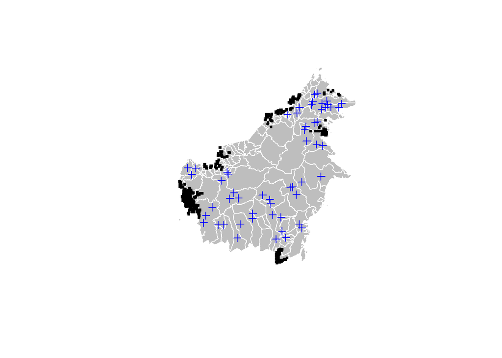

```r
plot(x = as(Borneo_shp, "Spatial"), col = 'grey', border = 'white')
points(x = sp_recs$long, sp_recs$lat, cex = 0.5, pch = 15)
plot(x = as(sp_shp, "Spatial"), col = 'blue', add = T) # easy handling of shapefiles
```

```r
sp_recs_sf <- st_as_sf(x = data.frame(sp_recs),
                       coords = c("long", "lat"),
                       crs = 4326,
                       sf_column_name = "geometry" )
```

## Spatial overlay - Points and Polygons

```r
# retrieve the geometry (location) indices of PA_shp at
# the locations of sp_recs: which points are in PA_shp
insidePA <- st_intersection(x = sp_recs_sf, y = PA_shp)
```

## Spatial overlay - Points and Rasters

```r
# for a RASTER: extract mean ann. temp. from ras1
# and add it to a.t.
mean_t <- extract(x = ras1, y = sp_recs_sf)
sp_recs_sf$mean_t <- mean_t
mean(x = sp_recs_sf$mean_t) #hist(sp_recs@data$mean_t)
```

```
## [1] 272.7788
```

### Save and plot the new point layer

```r
st_write(obj = insidePA,
         dsn = output_wd,
         layer = 'inPA',
         driver ='ESRI Shapefile',
         update = TRUE,
         delete_layer = TRUE)
```

```
## Deleting layer `inPA' using driver `ESRI Shapefile'
## Updating layer `inPA' to data source `c:/Users/kramer/Dropbox/_TU_BiodivDynamics2019/output' using driver `ESRI Shapefile'
## features:       11
## fields:         5
## geometry type:  Point
```